# Project Foundations for Data Science: FoodHub Data Analysis

### **Question 7**: Which are the top 5 restaurants in terms of the number of orders received?

```python
df['restaurant_name'].value_counts()
```

| restaurant_name | count |
| --- | --- |
| Shake Shack | 219 |
| The Meatball Shop | 132 |
| Blue Ribbon Sushi | 119 |
| Blue Ribbon Fried Chicken | 96 |
| Parm | 68 |
| ... | ... |
| Sushi Choshi | 1 |
| Dos Caminos Soho | 1 |
| La Follia | 1 |
| Philippe Chow | 1 |
| 'wichcraft | 1 |

178 rows × 1 columns

**dtype:** int64

#### Observations:

The value counts function allows us to see the top 5 restaurant of number of orders that it recieves, since its a "count" and it just repeats how often it is counted. In this case, we can see the top 5 restaurants are the following:

1. Shake Shack with 219 orders
2. The Meatball Shop with 132
3. Blue Ribbon Sushi with 119
4. Blue Ribbon Fried Chicken with 96
5. Parm with 68

### **Question 8**: Which is the most popular cuisine on weekends?

```python
# Filter the data for weekends
weekend_orders = df[df['day_of_the_week'].isin(['Weekend'])]

# Find the most ordered cuisine on weekends
most_ordered_cuisine = weekend_orders['cuisine_type'].value_counts().idxmax()

# Display the result
print("Most ordered food on the weekend:", most_ordered_cuisine)
```

```
Most ordered food on the weekend: American
```

#### Observations:

We can clearly see that the most popular cuisine type is american. This is not a strange fact as we previously saw that the most popular restaurant is Shake shack.

### **Question 9**: What percentage of the orders cost more than 20 dollars?

```python
# Count the total number of orders, len is a function that counts
total_orders = len(df)

# we are asking to count the data, where the filter specifies it has to be a value above 20
orders_above_20 = len(df[df['cost_of_the_order'] > 20])

# Calculate the percentage by percentage rule
percentage_above_20 = (orders_above_20 / total_orders) * 100

print("Number of orders that cost above 20 dollars is: ", orders_above_20)
print(f"The percentage of orders costing more than $20 is: {percentage_above_20:.2f}%")
```

```
Number of orders that cost above 20 dollars is:  555
The percentage of orders costing more than $20 is: 29.24%
```

#### Observations:

555 of 1898 orders being above 20 says people are willing to spend a lot of money on the platform. This could also be infered that it could be where people order as a group (multiple people in a single order) or more expensive items in the menu. Since it is almost 30 (although specifically 29,24%), it is safe to assume that more expensive items on different menus do have a potential of being purchased.

### **Question 10**: What is the mean order delivery time?

```python
mean_delivery_time = df['delivery_time'].mean()

print("The mean delivery time is:", mean_delivery_time)
```

```
The mean delivery time is: 24.161749209694417
```

#### Observations:

This information could also be taken out by the data summary as it does give the mean per column, and we can verify that the result in both codes was the same. The mean delivery time is not that high, and it seems like an appropriate time frame for delivery, especially considering their max is 33 and their minimum is 15.

### **Question 11:** The company has decided to give 20% discount vouchers to the top 3 most frequent customers. Find the IDs of these customers and the number of orders they placed

```python
customer = df['customer_id'].value_counts().head(3)
print("Most loyal customers: ", customer)
```

```
Most loyal customers:  customer_id
52832    13
47440    10
83287     9
Name: count, dtype: int64
```

```python
customer = df['customer_id'].value_counts().head(3) #get the list of customers who buy most often

# Get the customer IDs as a list
top_customers = customer.index

# Filter the dataset with the list we previously made
top_customers_data = df[df['customer_id'].isin(top_customers)]

# im basically telling the code to group by each customer id, and by each customer id add by each cost of the order
total_spent_by_top_customers = top_customers_data.groupby('customer_id')['cost_of_the_order'].sum()

print("Total money spent by the most loyal customers:")
print(total_spent_by_top_customers)
```

```
Total money spent by the most loyal customers:
customer_id
47440    158.18
52832    225.80
83287    139.31
Name: cost_of_the_order, dtype: float64
```

#### Observations:

I added how much each customer has spent for fun, the number of repeated orders is not the high and their bill seems to be moderate. They don't spend too much money each time they order, as 158.18 dollars for customer 47440 spread in 10 orders seems to be fair.

### **Question 12**: Perform a multivariate analysis to explore relationships between the important variables in the dataset. (It is a good idea to explore relations between numerical variables as well as relations between numerical and categorical variables)

[figure not shown]

```python
sns.pairplot(df)
```

Pairplot is clearly not a good example of how to visualize the data in this case.

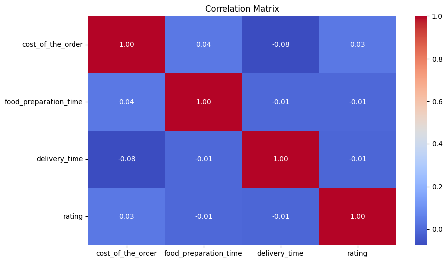

```python
filter = df[df['rating'] != 'Not given'] #im filtering out all the values that have the not given function

filter['rating'] = pd.to_numeric(filter['rating']) #using the pandas function of converting this from object to numeric

# Select numerical columns for correlation
numerical_columns = ['cost_of_the_order', 'food_preparation_time', 'delivery_time', 'rating']

# corr matrix
corr_matrix = filter[numerical_columns].corr()


plt.figure(figsize=(10, 6))
sns.heatmap(corr_matrix, annot=True, cmap='coolwarm', fmt='.2f')
plt.title("Correlation Matrix")
plt.show()
```

No big correlations between the data.

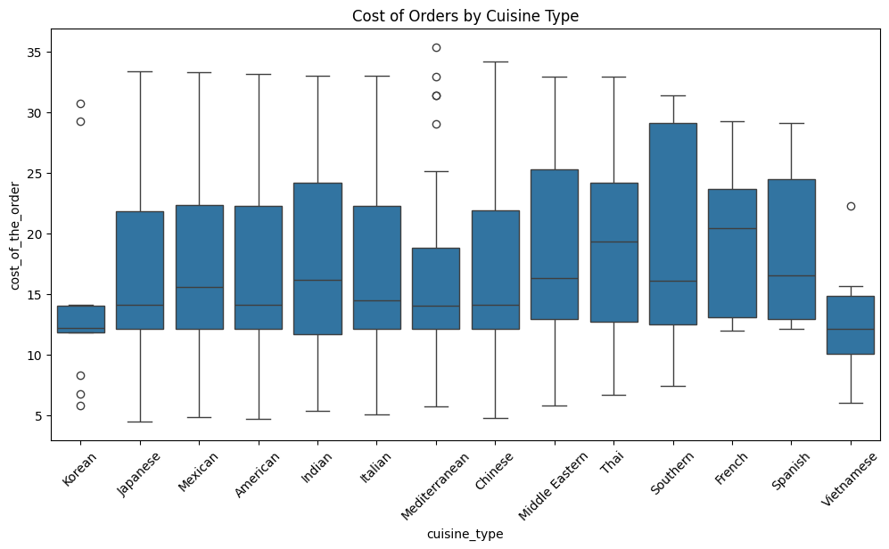

```python
plt.figure(figsize=(12, 6))
sns.boxplot(data=df, x='cuisine_type', y='cost_of_the_order')
plt.xticks(rotation=45)
plt.title("Cost of Orders by Cuisine Type")
plt.show()
```

Prices vary a lot depending on the type of food, but among the cheapest cuisine types (according to the median) are:

1. Korean
2. Vietnamese
3. American
4. Mediterranean
5. Chinese

Even so, the cost of order doesn't define the popularity. Meaning, customers are willing to pay for what food they crave and price might not be a deciding factor.

Data outliers are in korean food, mediterranean and vietnamese.

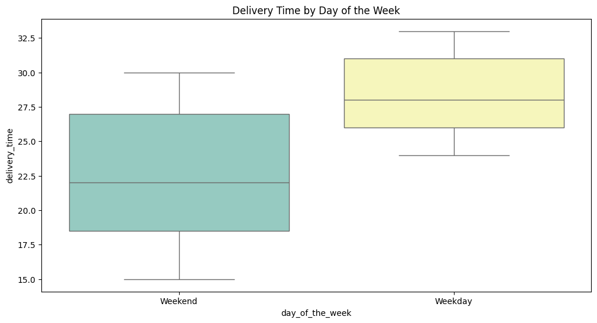

```python
plt.figure(figsize=(12, 6))
sns.boxplot(data=df, x='day_of_the_week', y='delivery_time', palette='Set3')
plt.title("Delivery Time by Day of the Week")
plt.show()
```

Weekend has faster delivery time than the weekday even though they have a higher range of time. Even so, weekday takes waay longer in comparasion to the mean.

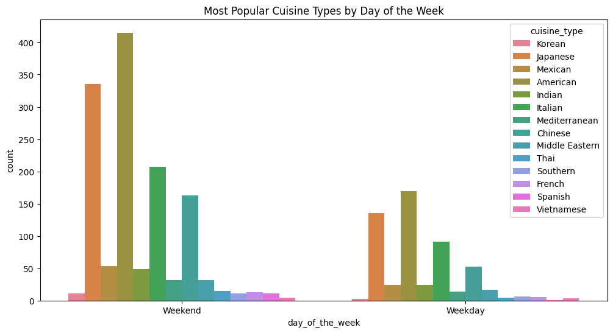

```python
plt.figure(figsize=(12, 6))
sns.countplot(data=df, x='day_of_the_week', hue='cuisine_type')
plt.title("Most Popular Cuisine Types by Day of the Week")
plt.show()
```

The four most common cuisine types don't vary a lot according to the day of the week, as the most common in both weekend and weekday are Japanese, American, Italian and Chinese. The only "differences" is that there are a lot more orders during the weekend.

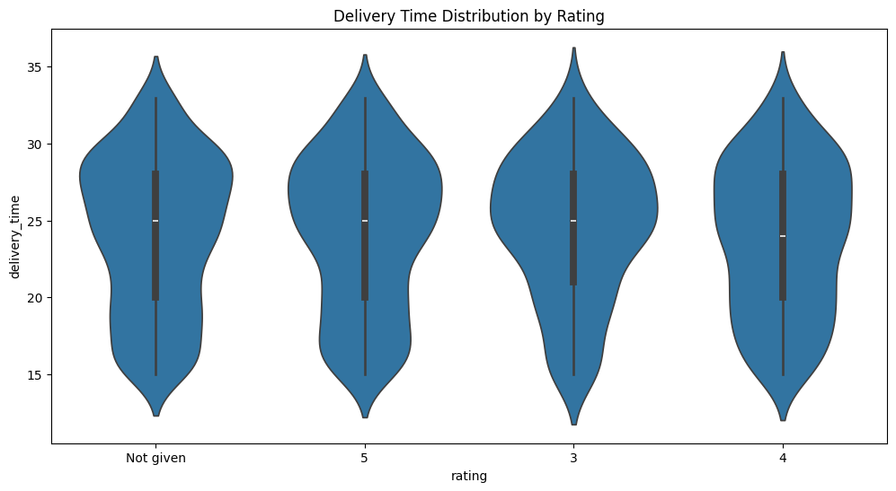

```python
plt.figure(figsize=(12, 6))
sns.violinplot(data=df, x='rating', y='delivery_time')
plt.title("Delivery Time Distribution by Rating")
plt.show()
```

Delivery time doesnt seem to be a deciding factor for the rating. They give the rating based on the quality of the food, as the mean appears to be the same in all of them.

### **Question 13:** The company wants to provide a promotional offer in the advertisement of the restaurants. The condition to get the offer is that the restaurants must have a rating count of more than 50 and the average rating should be greater than 4. Find the restaurants fulfilling the criteria to get the promotional offer

```python
filter = df[df['rating'] != 'Not given'] #im filtering out all the values that have the not given function

filter['rating'] = pd.to_numeric(filter['rating']) #using the pandas function of converting this from object to numeric

restaurant_data = filter.groupby('restaurant_name')['rating'].agg(['count', 'mean']) #agregating function by count (how many orders) and by mean (rating)

qualifying_restaurants = restaurant_data[(restaurant_data['count'] > 50) & (restaurant_data['mean'] > 4)]
#from the previously aggregated function that gave me two columns of count and mean, im now telling it to return values where count is above 50
#and where the mean of the rating is above 4

print("Restaurants that can recieve promotional offer:")
print(qualifying_restaurants)
```

```
Restaurants that can recieve promotional offer:
                           count      mean
restaurant_name
Blue Ribbon Fried Chicken     64  4.328125
Blue Ribbon Sushi             73  4.219178
Shake Shack                  133  4.278195
The Meatball Shop             84  4.511905
```

#### Observations:

It is logical that the most popular places, which we checked previously, will be the ones with the highest ratings and order count. The information checks out and these places are the mayor contributors to the highest orders.

### **Question 14:** The company charges the restaurant 25% on the orders having cost greater than 20 dollars and 15% on the orders having cost greater than 5 dollars. Find the net revenue generated by the company across all orders

```python
#create a function where we are basically telling it that if the order is above 20, do a 25% charge.
#else if (elif), if the order is above 5 dollars, do a 15% charge, and if it doesnt meet any of those conditions, dont charge anything
def calculate(order_cost):
    if order_cost > 20:
        return order_cost * 0.25  # 25% charge
    elif order_cost > 5:
        return order_cost * 0.15  # 15% charge
    else:
        return 0  # No charge for orders less or equal to 5 dollars

#apply the previous function to the column cost of order and save it all in the new dataframe revenue
df['revenue'] = df['cost_of_the_order'].apply(calculate)

#of everything done in the previous step, just add up revenue
total_revenue = df['revenue'].sum()

money = df['cost_of_the_order'].sum()

percentage_of_revenue = (total_revenue / money) * 100


print("Money coming in: $", money)

print("Total revenue generated by the company: $", total_revenue)

print("Of the total money coming in, " , percentage_of_revenue , "% is revenue.")
```

```
Money coming in: $ 31314.82
Total revenue generated by the company: $ 6166.303
Of the total money coming in,  19.691325065895317 % is revenue.
```

#### Observations:

I wanted to make the comparasion of the total money coming in and the revenue generated by the company. Of all the money coming in, roughly 19.69% is revenue. Revenue from the small orders that are below 20 dollars barely generate revenue in comparasion to the bigger orders, so there is a high dependence of orders above 20 dollars.

### **Question 15:** The company wants to analyze the total time required to deliver the food. What percentage of orders take more than 60 minutes to get delivered from the time the order is placed? (The food has to be prepared and then delivered)

```python
#calculate total delivery time, which is food prep + delivery
df['total_time'] = df['food_preparation_time'] + df['delivery_time']

#filter the data of total time we did previously where we only want the total to be above 60
orders_above_60 = df[df['total_time'] > 60]

#calculate percentage with shape
percentage_above_60 = (orders_above_60.shape[0] / df.shape[0]) * 100


print("Percentage of orders taking more than 60 minutes: " ,percentage_above_60, "%")
```

```
Percentage of orders taking more than 60 minutes:  10.537407797681771 %
```

#### Observations:

The number of orders that take more than 60 minutes is very low, as it is just 10.54 %. This could be because of big orders that are for families, groups, hangouts, etc which could take a long preparation time. Another additional factor could be rush hour, traffic, etc. Even so, the percentage is very low which could guarantee a high satisfaction rate.

### **Question 16:** The company wants to analyze the delivery time of the orders on weekdays and weekends. How does the mean delivery time vary during weekdays and weekends?

```python
df['day_of_the_week'].value_counts()
```

| day_of_the_week | count |
| --- | --- |
| Weekend | 1351 |
| Weekday | 547 |

**dtype:** int64

```python
weekday = df[df['day_of_the_week'] == 'Weekday']['delivery_time'].mean()
weeknd =  df[df['day_of_the_week'] == 'Weekend']['delivery_time'].mean()

print('The mean delivery time of the weekend is: ', weeknd)
print('The mean delivery time of the weekday is: ', weekday)
```

```
The mean delivery time of the weekend is:  22.4700222057735
The mean delivery time of the weekday is:  28.340036563071298
```

#### Observations:

I wanted to check the amount of deliveries that are during the weekend in comparasion to during the week. It is clear to see that there are way more orders during the weekend; and because of that, you'd think that the mean delivery time during the week would be less. However, it makes sense for the mean delivery time during the weekend to be less as there could be more drivers readily available to take on the orders.

### Conclusion and Recommendations

### **Question 17:** What are your conclusions from the analysis? What recommendations would you like to share to help improve the business? (You can use cuisine type and feedback ratings to drive your business recommendations)

### Conclusions:

- There aren't to many correlations, but there are patterns. No correlations in the matrix data.
- The most popular places offer cuisine types of american, japanese, chinese, etc.
- The highest rated restaurants offered these types of food as well.
- Weekends are busier than weekdays.

### Recommendations:

- Give promotions to promote the orders to be bigger than 20 dollars, as most revenue is generated there.
- Value your high value customers that are willing to spend more and order frequently.
- Give very small discounts or do a point reward system to people who commonly give ratings and provide feedback.
- Give more incentives for the weekdays to have more people, like promotions.
- Even though weekdays have less orders, delivery times are slower. Work on making delivery times faster so there is a bigger satisfaction rate and people could be motivated to order more during the week.

```python
pip install nbconvert
```